# Problem Set 1

Author

Sam Turner

Published

September 21, 2022

# The Popularity of Baby Names

Install and load the package `babynames`. Get help for `?babynames` to see what the data includes. **Also, don’t forget to load `tidyverse`**!

```r
#install.packages("babynames")
library(babynames)
library(tidyverse)
babynames
```

```
# A tibble: 1,924,665 × 5
    year sex   name          n   prop
   <dbl> <chr> <chr>     <int>  <dbl>
 1  1880 F     Mary       7065 0.0724
 2  1880 F     Anna       2604 0.0267
 3  1880 F     Emma       2003 0.0205
 4  1880 F     Elizabeth  1939 0.0199
 5  1880 F     Minnie     1746 0.0179
 6  1880 F     Margaret   1578 0.0162
 7  1880 F     Ida        1472 0.0151
 8  1880 F     Alice      1414 0.0145
 9  1880 F     Bertha     1320 0.0135
10  1880 F     Sarah      1288 0.0132
# … with 1,924,655 more rows
```

## Question 1

### Part A

What are the top 5 boys names for 2017, and what *percent* (note *not* the proportion!) of overall names is each?

```r
# write your code here!
total_boys <- babynames %>%
  filter(sex == "M" & year == 2017) %>% #Querey for sex and the year
  select(n) %>% #Grab the total boy births in a year
  sum() #Sum all together to get total amount of boys that year

boy_babynames <- babynames %>%
  filter(sex == "M" & year == 2017) %>% #Querey again for sex and year
  mutate(percnt = 100*(n / total_boys)) %>% #Calculate percentage of boys and assign it to percnt
  arrange(desc(percnt)) #Arrange DataFrame in decending order, putting highest first
```

The top five boys names for 2017 are as follows:

1. Liam with 1.0208832%
2. Noah with 0.9989697%
3. William with 0.8124329%
4. James with 0.7758014%
5. Logan with 0.7617376%

### Part B

What are the top 5 *girls* names for 2017, and what *percent* of overall names is each?

```r
# write your code here!
total_girls <- babynames %>%
  filter(sex == "F" & year == 2017) %>%
  select(n) %>%
  sum()

girl_babynames <- babynames %>%
  filter(sex == "F" & year == 2017) %>%
  mutate(percnt = 100*(n / total_girls)) %>%
  arrange(desc(percnt))

babynames
```

```
# A tibble: 1,924,665 × 5
    year sex   name          n   prop
   <dbl> <chr> <chr>     <int>  <dbl>
 1  1880 F     Mary       7065 0.0724
 2  1880 F     Anna       2604 0.0267
 3  1880 F     Emma       2003 0.0205
 4  1880 F     Elizabeth  1939 0.0199
 5  1880 F     Minnie     1746 0.0179
 6  1880 F     Margaret   1578 0.0162
 7  1880 F     Ida        1472 0.0151
 8  1880 F     Alice      1414 0.0145
 9  1880 F     Bertha     1320 0.0135
10  1880 F     Sarah      1288 0.0132
# … with 1,924,655 more rows
```

The top 5 girls names for 2017 are as follows:

1. Emma with 1.1530479%
2. Olivia with 1.0884379
3. Ava with 0.9289577%
4. Isabella with 0.8821067%
5. Sophia with 0.8663924%

## Question 2

Make two barplots of these top 5 names, one for each sex. Map `aes`thetics `x` to `name` and `y` to `prop` [or `percent`, if you made that variable, as I did.] and use `geom_col` (since you are declaring a specific `y`, otherwise you could just use `geom_bar()` and just an `x`.)

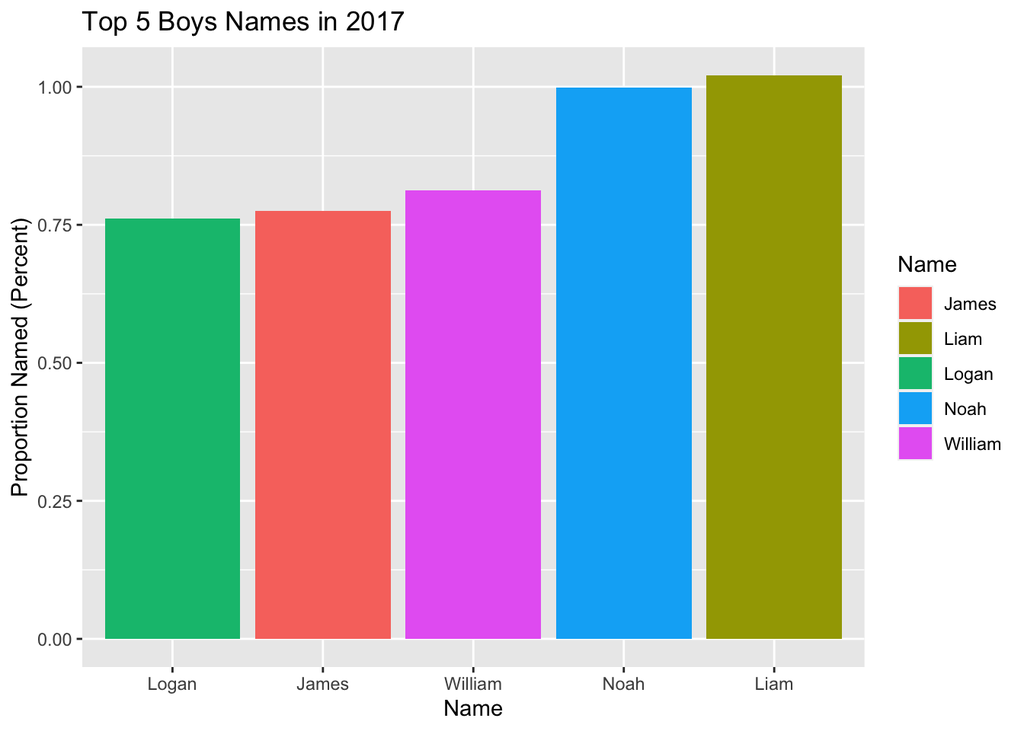

```r
# write your code here!
ggplot(data = boy_babynames %>% slice(1:5))+ #Grab first 5 rows
  aes(x=name,
      y=percnt,
      fill=name)+ #Use fill to color the graph
  geom_col(aes(reorder(name, percnt)))+ #Reorder the bars so that they look nicer
  labs(x="Name",
       y="Proportion Named (Percent)",
       title="Top 5 Boys Names in 2017",
       fill="Name")
```

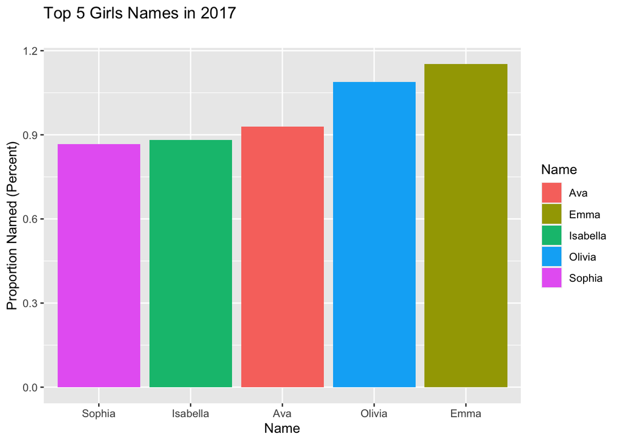

```r
ggplot(data = girl_babynames %>% slice(1:5))+
  aes(x=name,
      y=percnt,
      fill=name)+
  geom_col(aes(reorder(name, percnt)))+
  labs(x="Name",
       y="Proportion Named (Percent)",
       title="Top 5 Girls Names in 2017",
       subtitle="",
       fill="Name")
```

## Question 3

Find your name. [If your name isn’t in there 😟, pick a random name.] `count` by `sex` how many babies since 1880 were named your name. [Hint: if you do only this, you’ll get the number of *rows* (years) there are in the data. You want to add the number of babies in each row (`n`), so inside `count`, add `, wt = n` to weight the count by `n`.] Also create a variable for the percent of each sex.

```r
# write your code here!
boys_named_sam <- babynames %>%
  filter(name=="Samuel" | name=="Sam") %>%
  filter(sex=="M") %>%
  select(n) %>%
  sum()

girls_named_sam <- babynames %>%
  filter(name=="Samuel" | name=="Sam") %>%
  filter(sex=="F") %>%
  select(n) %>%
  sum()

percnt_boys <- 100*(boys_named_sam / (boys_named_sam + girls_named_sam))
percnt_girls <- 100*(girls_named_sam / (boys_named_sam + girls_named_sam))
```

Since 1880 there have been 873790 boys named Sam or Samuel. This makes up 99.5159674% of the total number of people named Sam or Samuel. In the same time period there have been 4250 named Sam or Samuel. They make up 0.4840326% of the population of people named Sam or Samuel.

## Question 4

Make a line graph of the number of babies with your name over time, `color`ed by `sex`.

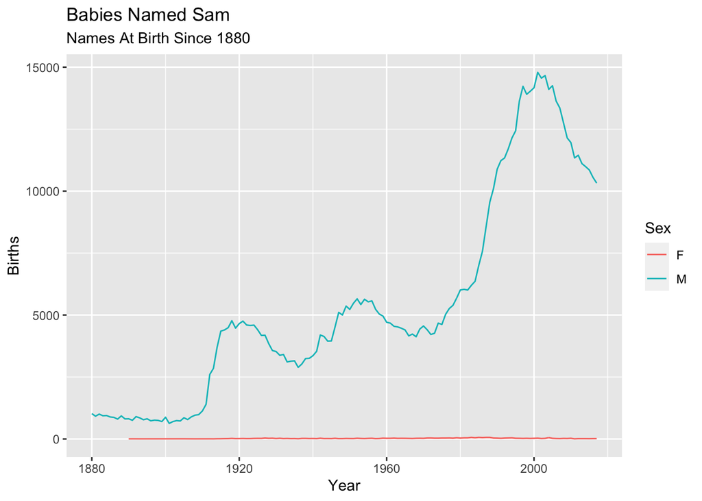

```r
# write your code here!
named_sam <- babynames %>%
  filter(name=="Samuel")

ggplot(data=named_sam)+
  aes(x=year,
      y=n)+
  geom_line(aes(color=sex))+
  labs(x="Year",
       y="Births",
       title="Babies Named Sam",
       subtitle="Names At Birth Since 1880",
       color="Sex")
```

## Question 5

### Part A

Find the most common name for boys by year between 1980-2017. [Hint: you’ll want to first `group_by(year)`. Once you’ve got all the right conditions, you’ll get a table with a lot of data. You only want to keep just the 1st row of each grouped-year’s data, so add `%>% slice(1)`.]

```r
# write your code here!
babynames %>%
  group_by(year) %>%
  filter(sex=="M") %>%
  arrange(desc(n)) %>%
  slice(1)
```

```
# A tibble: 138 × 5
# Groups:   year [138]
    year sex   name      n   prop
   <dbl> <chr> <chr> <int>  <dbl>
 1  1880 M     John   9655 0.0815
 2  1881 M     John   8769 0.0810
 3  1882 M     John   9557 0.0783
 4  1883 M     John   8894 0.0791
 5  1884 M     John   9388 0.0765
 6  1885 M     John   8756 0.0755
 7  1886 M     John   9026 0.0758
 8  1887 M     John   8110 0.0742
 9  1888 M     John   9247 0.0712
10  1889 M     John   8548 0.0718
# … with 128 more rows
```

### Part B

Now do the same for girls.

```r
# write your code here!
babynames %>%
  group_by(year) %>%
  filter(sex=="F") %>%
  arrange(desc(n)) %>%
  slice(1)
```

```
# A tibble: 138 × 5
# Groups:   year [138]
    year sex   name      n   prop
   <dbl> <chr> <chr> <int>  <dbl>
 1  1880 F     Mary   7065 0.0724
 2  1881 F     Mary   6919 0.0700
 3  1882 F     Mary   8148 0.0704
 4  1883 F     Mary   8012 0.0667
 5  1884 F     Mary   9217 0.0670
 6  1885 F     Mary   9128 0.0643
 7  1886 F     Mary   9889 0.0643
 8  1887 F     Mary   9888 0.0636
 9  1888 F     Mary  11754 0.0620
10  1889 F     Mary  11648 0.0616
# … with 128 more rows
```

## Question 6

Now let’s graph the evolution of the most common names since 1880.

### Part A

First, find out what are the top 10 *overall* most popular names for boys and for girls in the data. [Hint: first `group_by(name)`.] You may want to create two objects, each with these top 5 names as character elements.

```r
# write your code here!
top_ten_boys_names <- babynames %>%
  group_by(name) %>%
  filter(sex=="M") %>%
  count(name, wt = n) %>% #"wt" keeps tally of n for distinct name
  arrange(desc(n)) %>%
  head(n=5) %>%
  select(name) %>%
  pull()

top_ten_girls_names <- babynames %>%
  group_by(name) %>%
  filter(sex=="F") %>%
  count(name, wt = n) %>%
  arrange(desc(n)) %>%
  head(n=5) %>%
  select(name) %>%
  pull()
```

### Part B

Now make two `line`graphs of these 5 names over time, one for boys, and one for girls. [Hint: you’ll first want to subset the data to use for your `data` layer in the plot. First `group_by(year)` and also make sure you only use the names you found in Part A. Try using the `%in%` command to do this.]

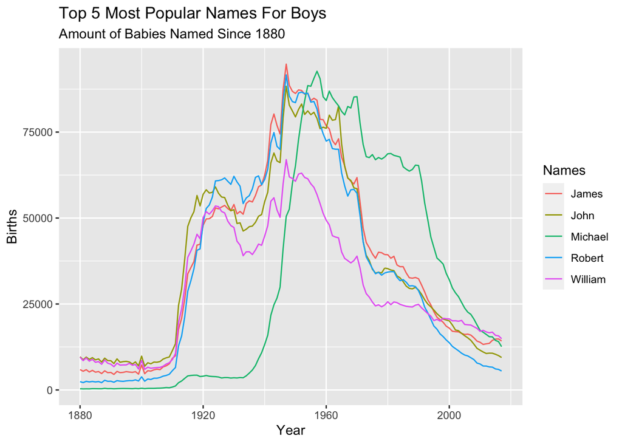

```r
# write your code here!
boys_subset <- babynames %>%
  filter(name %in% top_ten_boys_names) %>%
  filter(sex=="M")

girls_subset <- babynames %>%
  filter(name %in% top_ten_girls_names) %>%
  filter(sex=="F")

ggplot(data = boys_subset)+
  aes(x=year,
      y=n)+
  geom_line(aes(color=name))+
  labs(x="Year",
       y="Births",
       title="Top 5 Most Popular Names For Boys",
       subtitle="Amount of Babies Named Since 1880",
       color="Names")
```

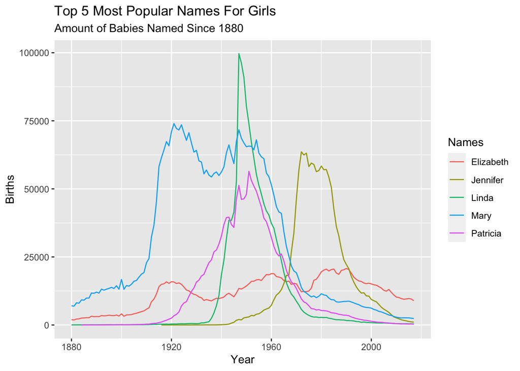

```r
ggplot(data = girls_subset)+
  aes(x=year,
      y=n)+
  geom_line(aes(color=name))+
  labs(x="Year",
       y="Births",
       title="Top 5 Most Popular Names For Girls",
       subtitle="Amount of Babies Named Since 1880",
       color="Names")
```

# Political and Economic Freedom Around the World

For the remaining questions, we’ll look at the relationship between Economic Freedom and Political Freedom in countries around the world today. Our data for economic freedom comes from the [Fraser Institute](https://www.fraserinstitute.org/economic-freedom/dataset?geozone=world&year=2016&page=dataset), and our data for political freedom comes from [Freedom House](https://freedomhouse.org/content/freedom-world-data-and-resources).

## Question 7

Download these two datasets that I’ve cleaned up a bit: [If you want a challenge, try downloading them from the websites and cleaning them up yourself!]

- [`econ_freedom.csv`](http://metricsf22.classes.ryansafner.com/data/econ_freedom.csv)
- [`pol_freedom.csv`](http://metricsf22.classes.ryansafner.com/data/pol_freedom.csv)

Below is a brief description of the variables I’ve put in each dataset:

### Econ Freedom

| Variable | Description |
| --- | --- |
| `year` | Year |
| `ISO` | Three-letter country code |
| `country` | Name of the country |
| `ef_index` | Total economic freedom index (0 - least to 100 - most) |
| `rank` | Rank of the country in terms of economic freedom |
| `continent` | Continent the country is in |

### Pol Freedom

| Variable | Description |
| --- | --- |
| `country` | Name of the country |
| `C/T` | Whether the location is a country (C) or territory (T) |
| `year` | Year |
| `status` | Whether the location is Free (F), Partly Free (PF) or Not Free (NF) |
| `fh_score` | Total political freedom index (0 - least to 100 - most) |

Import and save them each as an object using `my_df_name <- read_csv("name_of_the_file.csv")`. I suggest one as `econ` and the other as `pol`, but it’s up to you. Look at each object you’ve created.

```r
# write your code here!
econ <- read.csv("econ_freedom.csv")
pol <- read.csv("pol_freedom.csv")
```

## Question 8

Now let’s join them together so that we can have a single dataset to work with. You can learn more about this [in the 1.4 slides](https://metricsf21.classes.ryansafner.com/slides/1.4-slides#143). Since both datasets have both `country` and `year` (spelled exactly the same in both!), we can use these two variables as a `key` to combine observations. Run the following code (substituting whatever you want to name your objects):

```r
freedom <- left_join(econ, pol, # join pol tibble to econ tibble
                     by = c("country", "year")) # keys to match variables between two tibbles!
```

**Take a look at `freedom` to make sure it appears to have worked.**

```r
# write your code here!
freedom %>%
  glimpse()
```

```
Rows: 4,050
Columns: 9
$ year      <int> 2018, 2018, 2018, 2018, 2018, 2018, 2018, 2018, 2018, 2018, …
$ ISO       <chr> "ALB", "DZA", "AGO", "ARG", "ARM", "AUS", "AUT", "AZE", "BHS…
$ country   <chr> "Albania", "Algeria", "Angola", "Argentina", "Armenia", "Aus…
$ ef_index  <dbl> 7.80, 4.97, 4.75, 5.78, 7.92, 8.23, 7.80, 6.37, 7.62, 7.16, …
$ rank      <int> 26, 157, 159, 144, 18, 5, 26, 112, 39, 70, 133, 122, 114, 49…
$ continent <chr> "Europe", "Africa", "Africa", "Americas", "Asia", "Oceania",…
$ C.T       <chr> "c", "c", "c", "c", "c", "c", "c", "c", NA, "c", "c", "c", "…
$ status    <chr> "PF", "NF", "NF", "F", "PF", "F", "F", "NF", NA, "NF", "PF",…
$ fh_score  <int> 68, 35, 26, 83, 45, 98, 94, 12, NA, 12, 45, 96, 21, 95, 86, …
```

## Question 9

### Part A

Make a barplot of the 10 countries with the highest Economic Freedom index score in 2018. You may want to find this first and save it as an object to use for your plot’s `data` layer. Use `geom_col()` since we will map `ef_index` to `y`. If you want to order the bars, set `x = fct_reorder(ISO, desc(ef_index))` to reorder `ISO` (or `country`, if you prefer) by EF score in descending order.

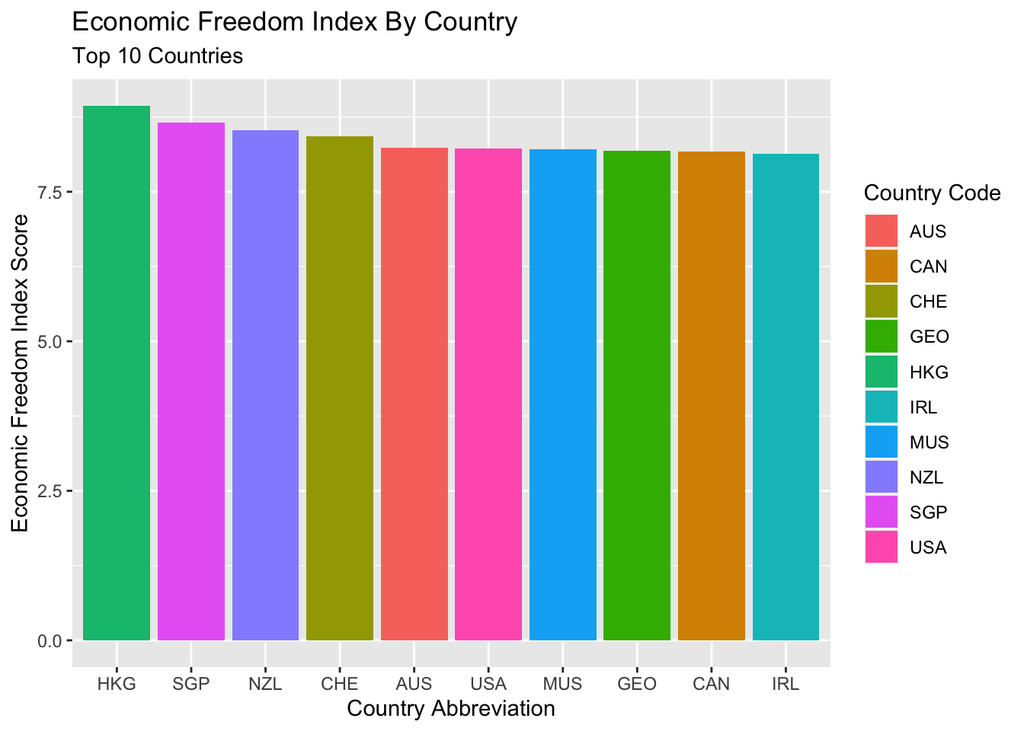

```r
# write your code here!
top_ten_freedom_2018 <- freedom %>%
  filter(year == 2018) %>%
  arrange(desc(ef_index)) %>%
  slice(1:10)

ggplot(data=top_ten_freedom_2018)+
  aes(x=fct_reorder(ISO, desc(ef_index)),
      y=ef_index,
      fill=ISO)+
  geom_col()+
  labs(x="Country Abbreviation",
       y="Economic Freedom Index Score",
       title="Economic Freedom Index By Country",
       subtitle="Top 10 Countries",
       fill="Country Code")
```

### Part B

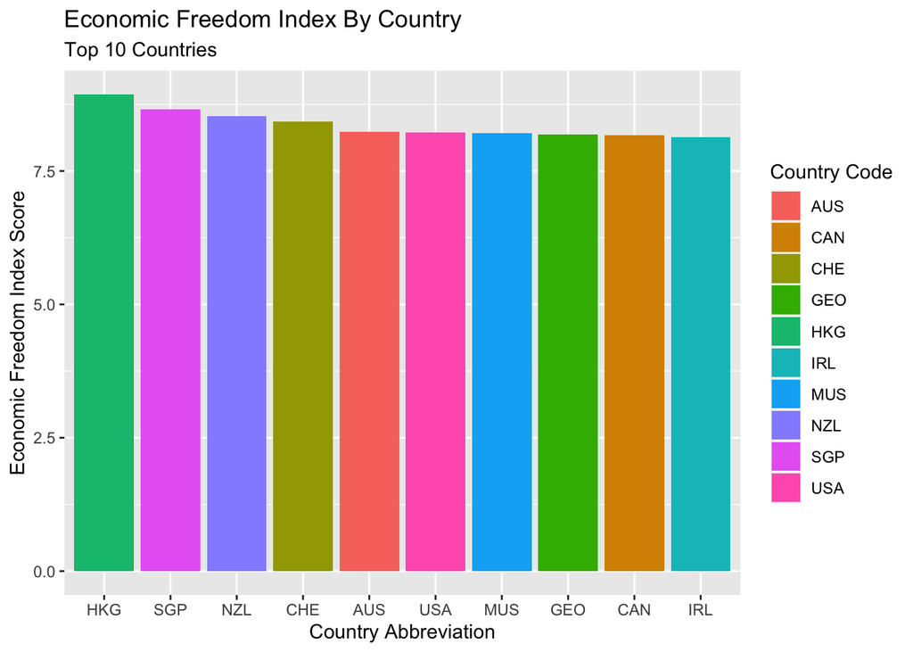

```r
# write your code here!
ggplot(data=top_ten_freedom_2018,
       aes(x=fct_reorder(ISO, desc(ef_index)),
           y=ef_index,
           fill=ISO))+
  geom_bar(stat = 'identity')+
  labs(x="Country Abbreviation",
       y="Economic Freedom Index Score",
       title="Economic Freedom Index By Country",
       subtitle="Top 10 Countries",
       fill="Country Code")
```

## Question 10

Now make a scatterplot of Political freedom (`fh_score` as `y`) on Economic Freedom (`ef_index` as `x`) in the year 2018, and `color` by `continent`.

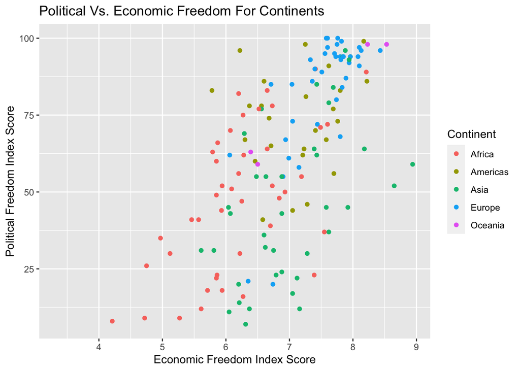

```r
# write your code here!
freedom_2018 <- freedom %>%
  filter(year==2018)

EFPFScatter <- ggplot(data=freedom_2018)+
  aes(x=ef_index,
      y=fh_score,
      color=continent)+
  geom_point()+
  labs(x="Economic Freedom Index Score",
       y="Political Freedom Index Score",
       title="Political Vs. Economic Freedom For Continents",
       color="Continent")

EFPFScatter
```

## Question 11

Save your plot from Question 10 as an object, and add a new layer where we will highlight a few countries. Pick a few countries (I suggest using the `ISO` code) and create a new object `filter`ing the data to only include these countries (again the `%in%` command will be most helpful here).

Additionally, *install* and *load* a package called `"ggrepel"`, which will adjust labels so they do not overlap on a plot.

Then, add the following layer to your plot:

```r
library(ggrepel)

cntry_list <- c("USA", "CAN", "HKG", "CHE")

countries <- freedom %>%
  filter(ISO %in% cntry_list)

geom_label_repel(data = countries, # or whatever object name you created
                   max.overlaps = getOption("ggrepel.max.overlaps", default = 20), #Need to change to get access to points
                   aes(x = ef_index,
                         y = fh_score,
                         label = ISO, # show ISO as label (you could do country instead)
                         color = continent),
                     alpha = 0.5, # make it a bit transparent
                     box.padding = 0.75, # control how far labels are from points
                     show.legend = F) # don't want this to add to the legend
```

```
mapping: x = ~ef_index, y = ~fh_score, label = ~ISO, colour = ~continent
geom_label_repel: parse = FALSE, box.padding = 0.75, label.padding = 0.25, point.padding = 1e-06, label.r = 0.15, label.size = 0.25, min.segment.length = 0.5, arrow = NULL, na.rm = FALSE, force = 1, force_pull = 1, max.time = 0.5, max.iter = 10000, max.overlaps = 20, nudge_x = 0, nudge_y = 0, xlim =…
stat_identity: na.rm = FALSE
position_identity
```

This should highlight these countries on your plot.

[figure not shown]

```r
# write your code here!
ggplot(data=countries)+
  aes(x=ef_index,
      y=fh_score,
      color=continent)+
  geom_point()+
  labs(x="Economic Freedom Index Score",
       y="Political Freedom Index Score",
       title="Political Vs. Economic Freedom For Continents",
       subtitle="Pictured Is USA, Canada, and Switzerland",
       color="Continent")+
  geom_label_repel(data = countries, # or whatever object name you created
                   max.overlaps = getOption("ggrepel.max.overlaps", default = 20), #Need to change to get access to points
                   aes(x = ef_index,
                         y = fh_score,
                         label = ISO, # show ISO as label (you could do country instead)
                         color = continent),
                     alpha = 0.5, # make it a bit transparent
                     box.padding = 0.75, # control how far labels are from points
                     show.legend = F) # don't want this to add to the legend
```

## Question 12

Let’s just look only at the United States and see how it has fared in both measures of freedom over time. `filter()` the data to look only at the United States (its `ISO` is `"USA"`). Use both a `geom_point()` layer and a `geom_path()` layer, which will connect the dots over time. Let’s also see this by labeling the years with an additional layer `geom_text_repel(aes(label = year))`.

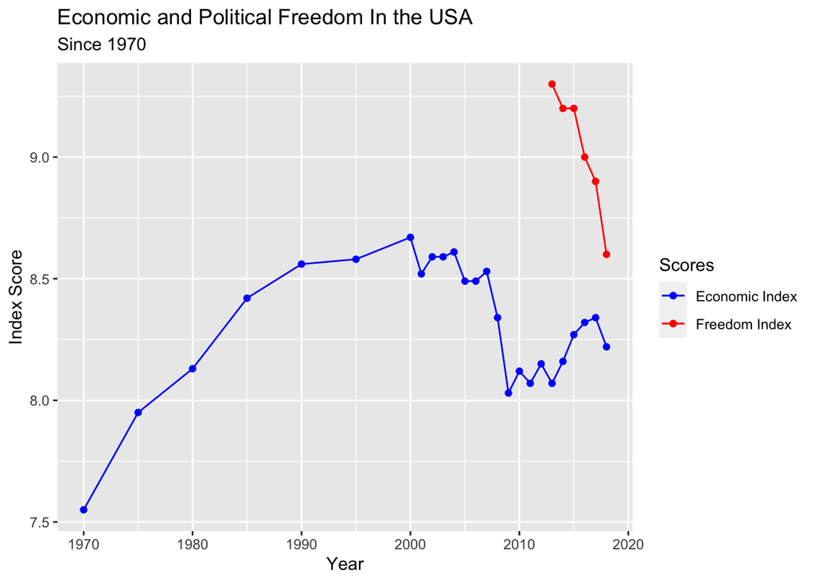

```r
# write your code here!
usa_freedom <- freedom %>%
  filter(ISO == "USA")

#Couldn't figure out how to pivot longer
ggplot(data=usa_freedom, aes(x=year))+
  geom_point(aes(y=ef_index, color="Economic Index"))+
  geom_path(aes(y=ef_index, color="Economic Index"))+
  geom_point(aes(y=fh_score/10, color="Freedom Index"))+
  geom_path(aes(y=fh_score/10, color="Freedom Index"))+
  scale_color_manual(name="Scores",
                     breaks = c('Economic Index', 'Freedom Index'),
                     values = c('Economic Index'='blue', 'Freedom Index'='red'))+
  labs(x="Year",
       y="Index Score",
       title="Economic and Political Freedom In the USA",
       subtitle="Since 1970")
```

# Knit and Submit!

When you are done, click the **Render** button. Based on the current `yaml` header `format: html`, this will currently produce an html webpage, which should automatically open for your review.

Notice in the **Files** pane in R Studio (by default, the lower right one), there should now be a document called `01-problem-set.html` (or if you changed the filename) ending in `.html`. This is the webpage, so you can find this file on your computer (or download it from Rstudio.cloud with by clicking on the checkmark box in front of the file in the Files page and then going to `More -> Export...` to download the file to your computer) and send this file.

Then change the format in the `yaml` header to `format: pdf` . Clicking **Render** will now produce a PDF, show it, and save it as a new file in the Files pane.

Either way, send me your output file, `html` or `pdf` (or, if you like, `word`) so long as it shows the input and output code of every chunk. I have set it by default to do this, with `echo: true` in the `yaml` header.

Don’t forget to add your name to the `author` part of the header!